# San Francisco Bay Bike-Sharing System Trip Characteristics

## by (Robert Gonpou Mesleh Jr)

## Investigation Overview

In this investigation, I want to look at when are most trips taken in the bike-sharing system covering the greater San Francisco Bay area, in terms of the time of day and day of the week. I also want to look at the average duration of the trips.

## Dataset Overview

The Ford GoBike dataset containes ride information about 183,412 trips made in a bike-sharing system covering the greater San Francisco Bay area. The datases contians trip information such as the date, duration, gender, birth year, and more. 8939 records with member year of birth older than 1950 were removed from the dataset.

## Bikers Demography - Gender and Rider Type

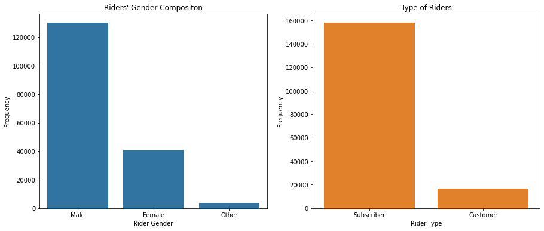

## Bikers Demography - Top 10 Year of Birth

This slide describes the top 10 birth year of the bikers. It provides an idication of which ages took the most rides in the San Francisco Bay area. Most riders were born between 1986 and 1995, with people from 1988 taking the most trip.

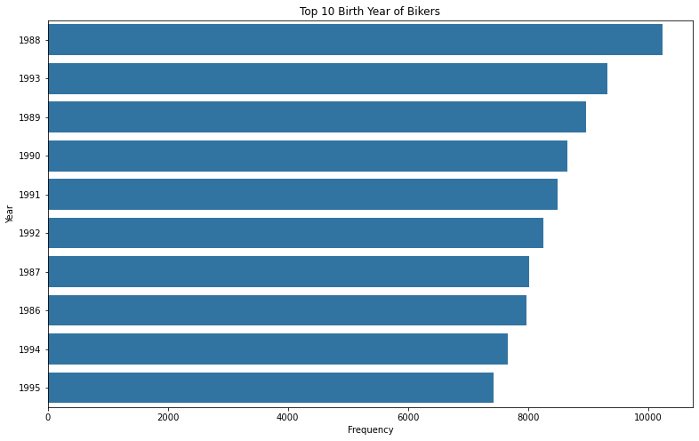

## Most Trips - Month Days and Hours

Most riders prefer to take their trips between 4:00pm - 6:00pm and 7:00am and 9:00am, with the most prefered time being 17:00hr.

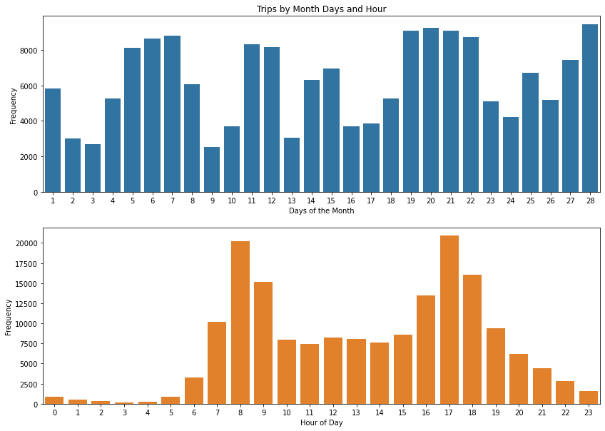

## Weekday With the Most Trips

When are most trips taken during the week? The results show that the most rides are on Thursdays. Despite Saturday and Sunday being weekend days where people are supposed to be free from work or school and engage is extra activties, they have the lowest number of trips.

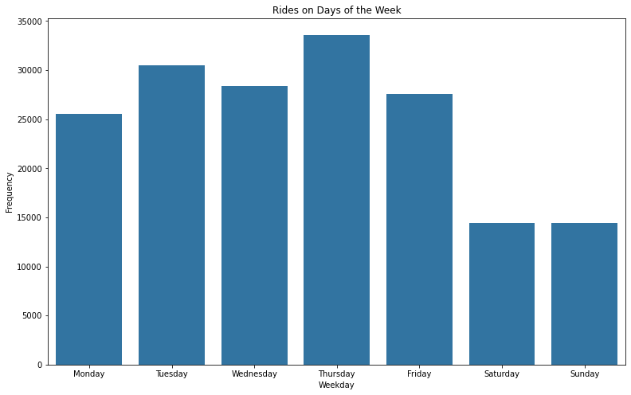

## Average Trip Duration

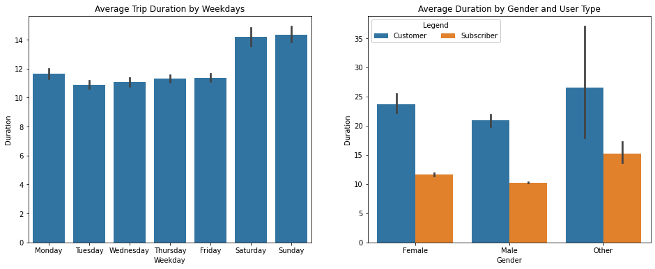